# How Low Income White Americans Vote

Rohan Uppuluri

9/23/2020

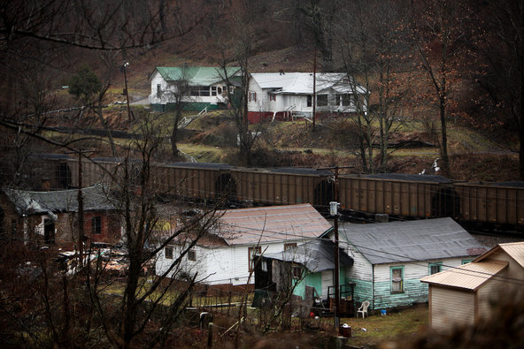

(image source: https://www.nytimes.com/times-insider/2014/04/23/penetrating-a-closed-isolated-society-in-appalachia/)

## Introduction

The Republican party supports the idea that the government should play a smaller role in people’s lives, especially in the economy (https://www.britannica.com/topic/Republican-Party). On the other hand, the Democratic Party supports the idea of a larger government that is more involved in people’s everyday lives (https://www.britannica.com/topic/Democratic-Party). Because the Democratic Party favors government programs like welfare, in theory it would make sense for more low income voters to vote for the Democratic Party than the Republican Party.

We will examine the voting behavior of low income, specifically white Americans, to see if this idea holds. In particular, we hope to answer the following questions:

-What is the presidential voting behavior of low income white Americans?

-What are some of the demographic differences between low income white Democrats and low income white Republicans that could help explain their different voting behavior?

## Preliminaries and Biases

We will be using the ANES time series data (1948-2016) to analyze the voting behavior and demographic information of low income white Americans. For the sake of this analysis, we will define low income as 0 to 33 percentile.

We will only examine voting behavior of low income white Democrats and Republicans. There is not as much data on Independent voters compared to that of the two main parties, and different Independent candidates do not necessarily share the same ideologies. Hence, it would be harder to narrow in on demographics of Independent voters throughout the years.

Normally, analyzing income data from surveys can be problematic since income can be an uncomfortable topic to discuss for some people, and this opens up the possibility of some respondents claiming to be in a higher income level than the income level they are actually in. However, a respondent does not have any incentive to say they are in a lower income level than their actual income level. Hence, we might lose a little bit of data due to low income respondents saying they are in a higher income level, but it is unlikely that we will have any data from respondents who are from a higher income level claiming to have low income. This means that all of the respondents we analyze who claim to have low income most likely actually have low income. Thus, by mainly analyzing low income respondents instead of medium to high income respondents, we remove some of this self-reporting bias.

## Income Breakdown of Voters

First, let’s do an income breakdown of all Democrat and Republican voters throughout the election years. Although there are some years where the very wealthy (96 to 100 percentile) have a smaller proportion of Republican voters compared to the other income groups, it looks like at first glance, lower income Americans are more likely to vote Democrat, and higher income Americans are more likely to vote Republican for the most part.

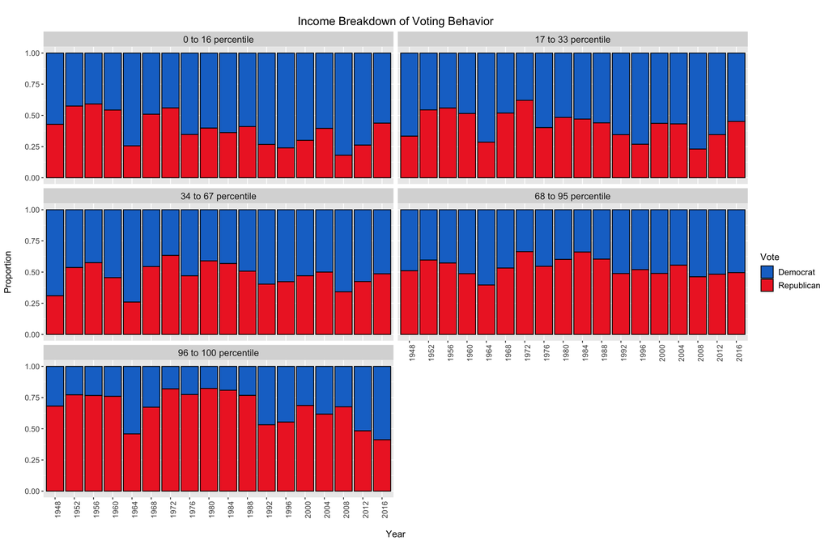

## Racial Breakdown of Income Levels

Now let’s look at what happens when we further break income levels down into white and non white respondents. It looks like income is not as related to voting behavior as had been indicated by the previous graphs. White Americans mostly vote Republican, and non white Americans mostly vote Democrat, regardless of income level.

The results from the previous graphs probably stem from the fact that there are significantly more white Americans than non white Americans who participated in the survey, which skewed the vote proportion toward white voter behavior.

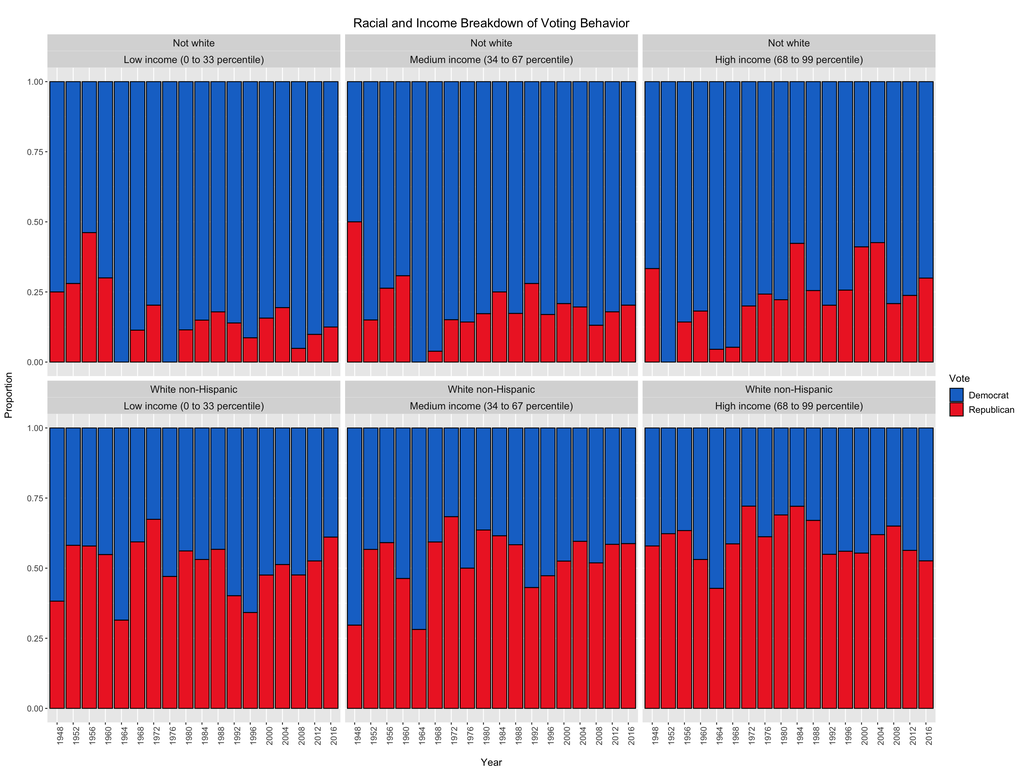

This phenomenon of low income white Americans mostly voting for the Republican Party even though the Democratic Party would theoretically offer more aid to them is a bit peculiar. To understand why this could be the case, we will examine the differences between low income white Republicans and low income white Democrats.

Note that for the rest of this analysis, I will use the terms Republicans and Democrats to refer to low income white Republicans and low income white Democrats.

## Differences in Religion

The first major demographic difference between the two types of voters is in religion. Regardless of the party, most low income white Americans are Christian (Protestant or Catholic), but a significantly higher proportion of Republicans are Protestant compared to the proportion of Protestants among Democrats.

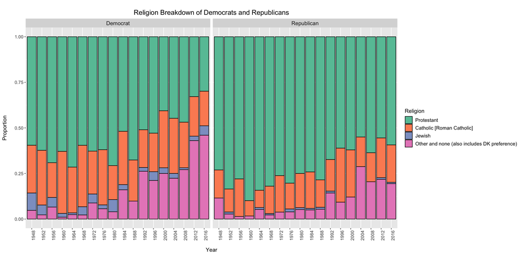

Next, out of the low income white Americans who are Christian, a higher proportion of Republicans believe in a fundamentalist interpretation of the Bible compared to Democrats. Also, a significantly higher amount of Democrats do not believe in the Bible at all despite being Christian, indicating that values from the Bible play a more important role in Republicans’ lives than Democrats.

Note that the three main answers for this survey question do not seem to capture all the possible feelings a voter can have toward the Bible, so I have kept ‘Other/DK’ (Don’t Know) as a valid response instead of filtering it out.

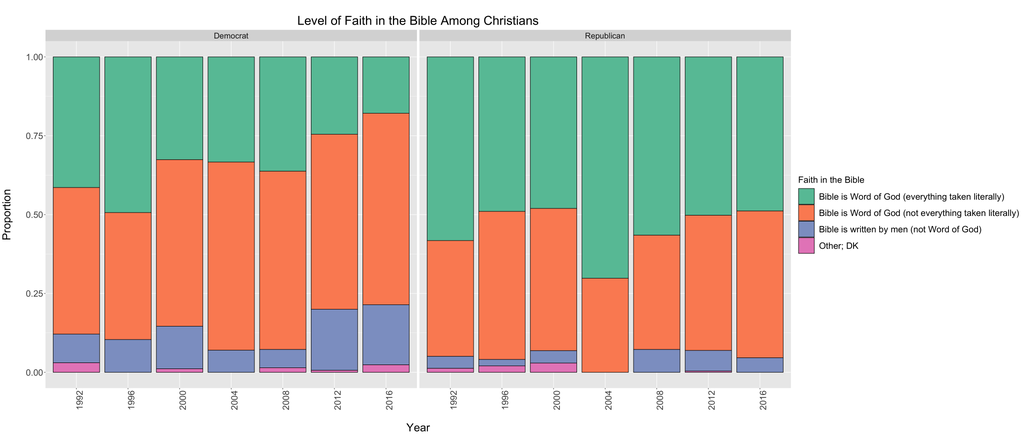

Out of the low income white Americans who are Christians, Republicans feel that Christianity has more guidance in their lives than it does for Democrats, and they have higher church attendance than Democrats. Along with a stronger belief in fundamentalism, having a higher church attendance and feeling more guidance from religion might contribute to their differences in political values from Democrats.

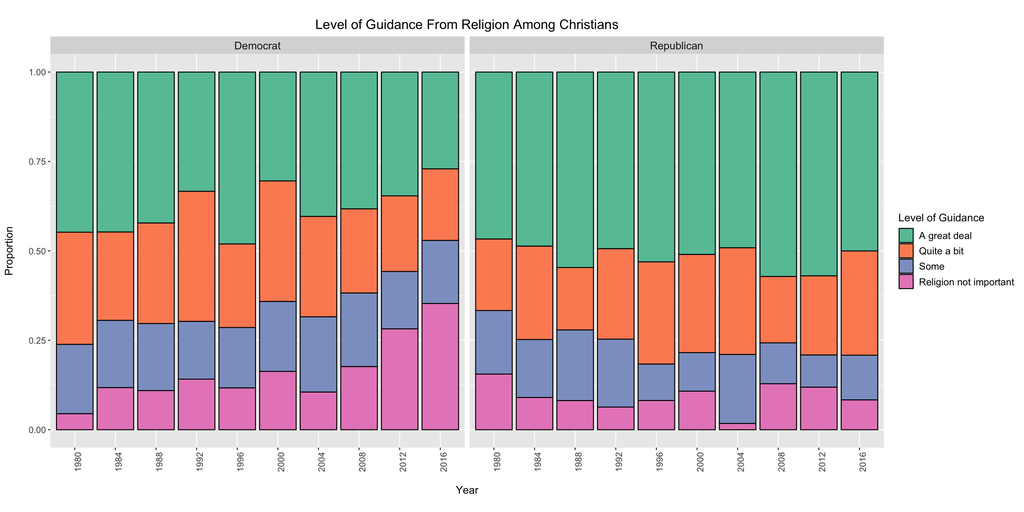

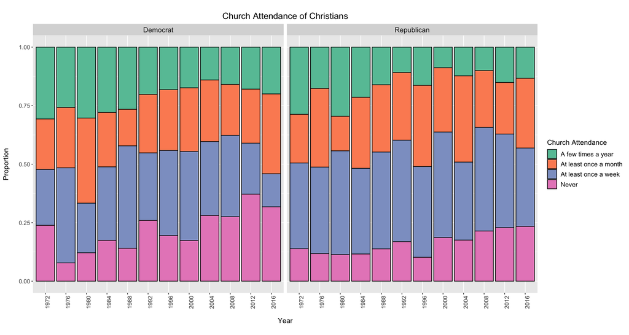

## Differences in Views on Family Ties and Government

A majority of Republicans agree that there should be more of an emphasis on a traditional family ties to solve problems. Democrats seemed to mostly share this sentiment until the past decade, and they now increasingly disagree with the idea that traditional family ties alone can solve problems. The survey does not explicitly say what traditional family ties refer to, but these results do reflect the philosophies of the respective parties. That is, Republicans believe that a strong community or family can solve most problems, while Democrats believe that those alone are not enough to solve all problems.

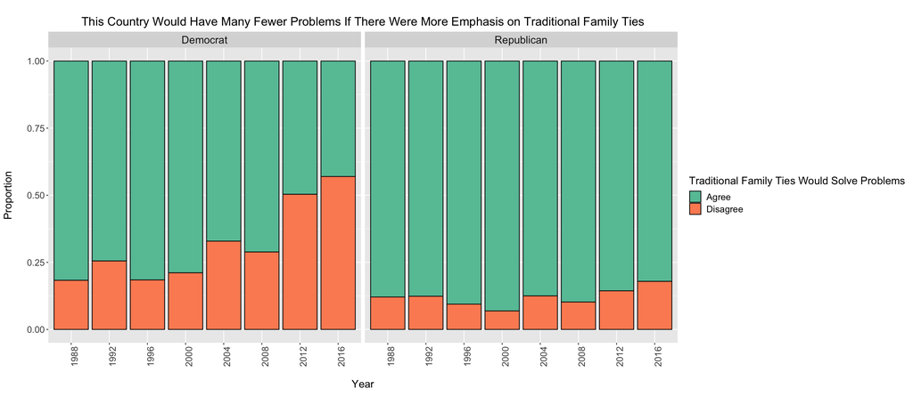

Most Republicans believe that the government has gotten too involved in things that people can do for themselves. Based on the previous results, Republicans most likely believe that family ties and a strong community should be involved in such issues instead of the government. On the other hand, most Democrats believe that the problems we face now are bigger and the role the government plays in our lives has increased appropriately as a result.

A problem with this survey question is that it implicitly assumes that the respondent believes that the government has become bigger in the first place. Hence, I have kept ‘DK; both, depends (1990,1992)’ as a valid response instead of filtering it out.

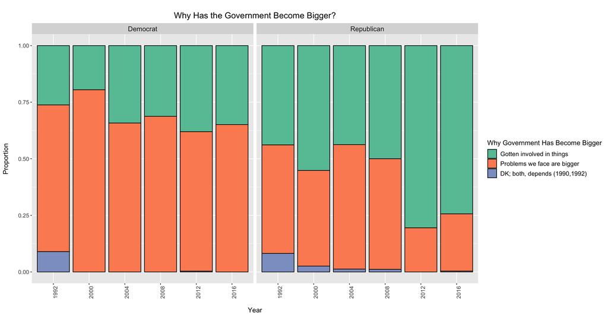

In terms of specific government programs, more low income white Republicans want welfare and other aid programs for low income Americans to stay the same/decrease compared to Democrats. This belief falls in line with how Republicans usually want less government control in their lives, especially in the economy. Thus, it looks like the belief in less government overrides a desire for an increase in financial security despite the fact that they are in the lowest income group.

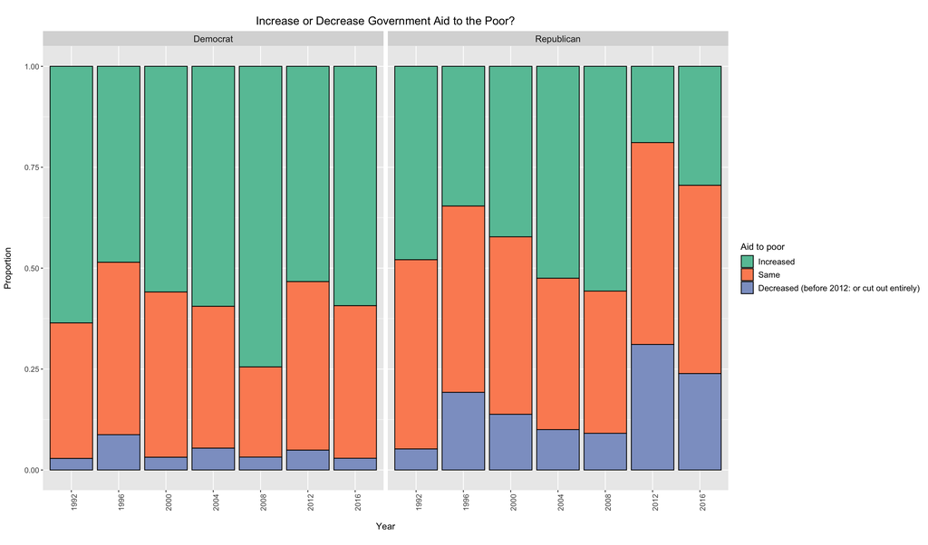

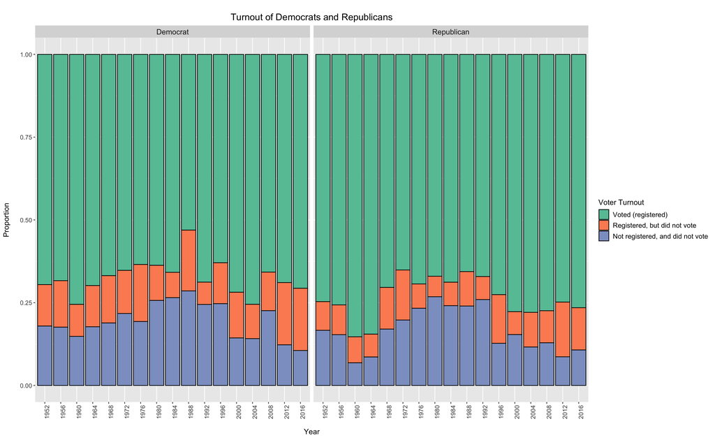

## Conclusion

In conclusion, this analysis establishes that a majority of low income white Americans have voted for the Republican Party over the years.

Despite the fact that the Democratic Party typically promises more government aid programs, most low income white Republicans emphasize family ties and a strong relationship with Christianity and their church to help with their everyday problems, including financial problems, rather than relying on the government. Moreover, their high emphasis on community and values informed by their religion are reflected in their high turnout rate so that they can have a government that supports those values but does not intrude on their community. On the other hand, many low income white Democrats are Christian as well, but religion typically plays less of a role in their lives, and they believe more in government aid like welfare programs.

However, there could be additional variables in the survey we did not explore or even variables that were not in the survey at all that could explain more about these differences in voting behavior. Note that attributes like age, gender, occupation, region, and education levels did not seem to indicate that a person would be more likely to vote Democrat or Republican, but I have omitted this result from the analysis to focus more on differences rather than similarities.

Finally, although we now know more about the demographic differences betweeen low income white Republicans and low income white Democrats, we still do not actually know for sure if these differences are merely correlated with their voting decisions or if they actually cause them to vote the way they do. We would need to use some causal inference techniques on the survey results or look at data other than the survey results to determine actual causal effects on low income white Americans’ voting behavior.